# Objetivo 3: Estudio aeropuertos y rutas.

A continuación, realizaremos un PCA para ver cuáles de las variables empleadas en el clusteting han contribuido más a la creación de los clusters obtenidos a partir de k-medias.

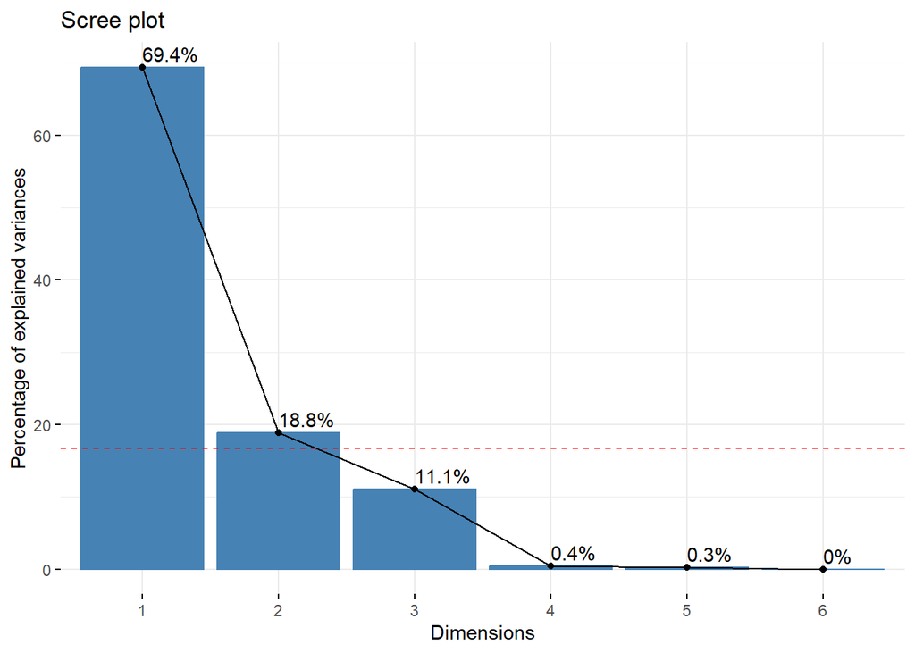

```r
misclust = factor(clust3$cluster)
miPCA = PCA(datos_aer_df, scale.unit = TRUE, graph = FALSE)
eig.val = get_eigenvalue(miPCA)
Vmedia = 100 * (1/nrow(eig.val))
fviz_eig(miPCA, addlabels = TRUE) +
  geom_hline(yintercept=Vmedia, linetype=2, color="red")
```

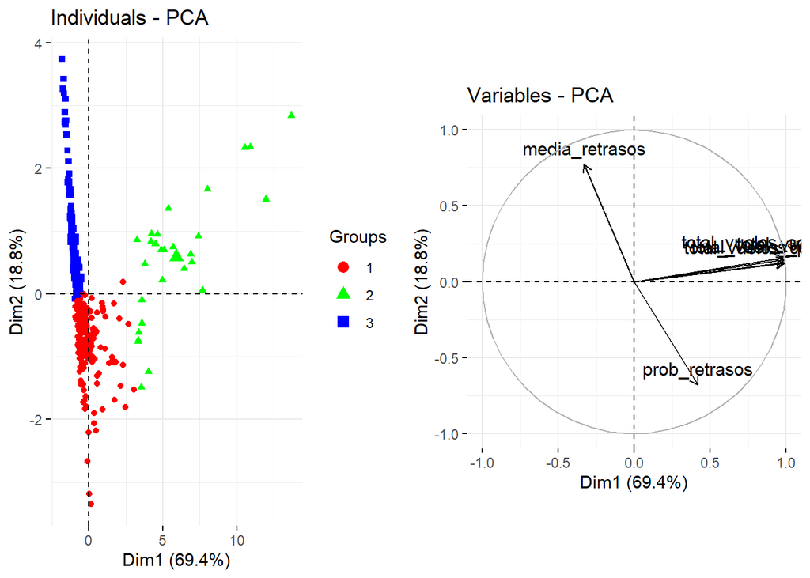

```r
p1 = fviz_pca_ind(miPCA, geom = "point", habillage = misclust, addEllipses = FALSE,
             palette = rainbow(3))
p2 = fviz_pca_var(miPCA)
grid.arrange(p1, p2, nrow = 1)
```

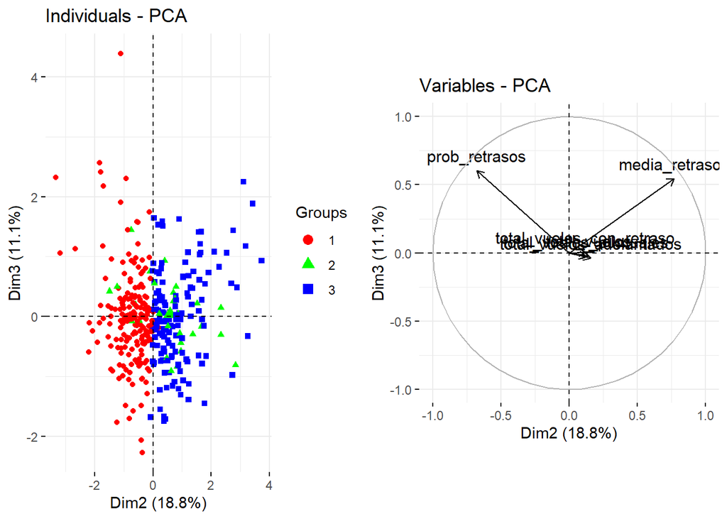

```r
p1 = fviz_pca_ind(miPCA,axes=c(2,3),geom = "point", habillage = misclust, addEllipses = FALSE,
             palette = rainbow(3))
p2 = fviz_pca_var(miPCA, axes=c(2,3))
grid.arrange(p1, p2, nrow = 1)
```

A partir de los gráficos de scores y loadings podemos ver cómo el segundo cluster parece crearse para los aeropuertos con gran número de vuelos independientemente de sus probabilidades de retraso y medias de retraso. Por otro lado, los clusters 1 y 3 parecen estar formados por aeropuertos con similar número de vuelos pero se distinguen en función de la probabilidad y media de retraso.

Para ayudar a la interpretación anterior de los clusters mediante PCA, realizaremos un gráfico descriptivo del perfil de cada cluster para observar las diferencias entre ellos. Para ello, calcularemos la media de cada variable para cada cluster.

```r
mediasCluster = aggregate(d_aer, by = list("cluster" = misclust), mean)[,-1]
rownames(mediasCluster) = paste0("c",1:3)
kable(t(round(mediasCluster,2)))
```

|  | c1 | c2 | c3 |
| --- | --- | --- | --- |
| total_vuelos | -0.15 | 2.95 | -0.39 |
| total_vuelos_con_retraso | -0.15 | 2.94 | -0.39 |
| total_vuelos_puntuales | -0.14 | 2.88 | -0.39 |
| total_vuelos_adelantados | -0.15 | 2.93 | -0.39 |
| media_retrasos | -0.52 | -0.51 | 0.79 |
| prob_retrasos | 0.46 | 0.87 | -0.78 |

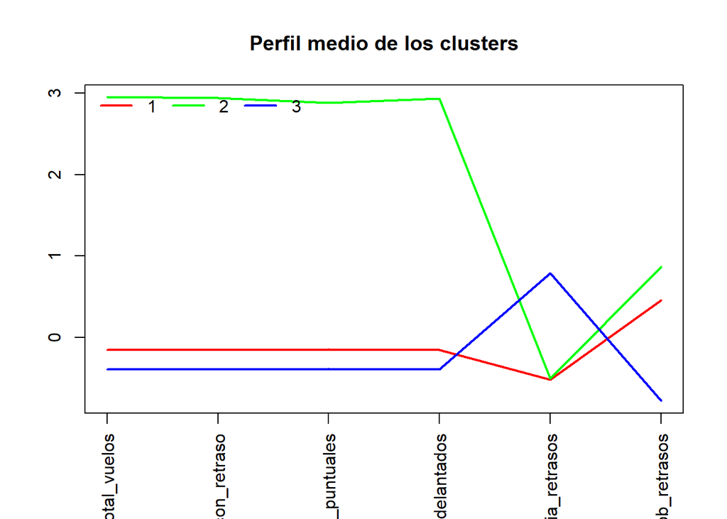

```r
matplot(t(mediasCluster), type = "l", col = rainbow(3), ylab = "", xlab = "", lwd = 2,
        lty = 1, main = "Perfil medio de los clusters", xaxt = "n")
axis(side = 1, at = 1:ncol(d_aer), labels = colnames(d_aer), las = 2)
legend("topleft", as.character(1:3), col = rainbow(3), lwd = 2, ncol = 3, bty = "n")
```

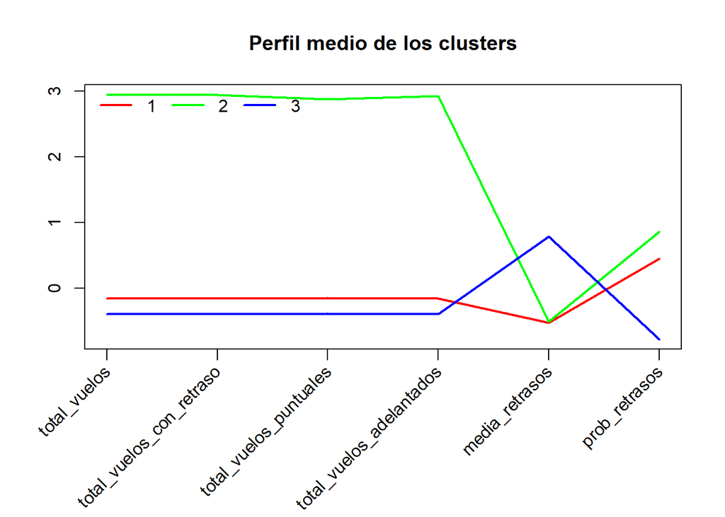

```r
# Ajustar los márgenes del gráfico
par(mar = c(8, 4, 4, 2) + 0.1)  # Aumenta el margen inferior

# Crear el gráfico con matplot
matplot(t(mediasCluster), type = "l", col = rainbow(3), ylab = "", xlab = "", lwd = 2,
        lty = 1, main = "Perfil medio de los clusters", xaxt = "n")

# Añadir el eje x sin etiquetas
axis(side = 1, at = 1:ncol(d_aer), labels = FALSE)

# Añadir las etiquetas giradas a 45 grados
text(x = 1:ncol(d_aer), y = par("usr")[3] - 0.3, srt = 45, adj = 1, labels = colnames(d_aer), xpd = TRUE)

# Añadir la leyenda
legend("topleft", as.character(1:3), col = rainbow(3), lwd = 2, ncol = 3, bty = "n")
```

En resumen, concluimos lo siguiente: -Cluster 1 (c1): Representa a los aeropuertos con bajo número de vuelos (baja actividad) con una probabilidad de retraso notable. -Cluster (c2): Formado por aeropuertos con bastantes vuelos (alta actividad) y con una notable probabilidad de retraso, a pesar de ello, estos retrasos no parecen ser muy largos. -Cluster (c3): Agrupa aeropuertos con bajo número de vuelos (baja actividad) y con retrasos largos. Sin embargo, poseen una baja probabilidad de retraso.

Creamos 3 subdatasets distintos que albergan los aeropuertos de cada cluster:

```r
data_aer_df <- as.data.frame(d_aer)

data_aer_df$cluster <- misclust


cluster1_df <- data_aer_df %>% filter(cluster == 1)
cluster2_df <- data_aer_df %>% filter(cluster == 2)
cluster3_df <- data_aer_df %>% filter(cluster == 3)
```

```r
aeropuertos_RES$indice_medio=((aeropuertos_RES$prob_retraso_origen*aeropuertos_RES$retraso_medio_origen)+(aeropuertos_RES$prob_retraso_destino*aeropuertos_RES$retraso_medio_destino))/2
```

# 3 Estudio de las rutas

Comenzamos a continuación, con el estudio de las rutas. Al igual que en el estudio de los aeropuertos guardamos en la variable resumen_rutas la siguiente información para cada ruta: **total_vuelos**: Número total de vuelos hechos en esa ruta.  
**vuelos_retrasados**: Número total de vuelos retrasados en de esa ruta.  
**vuelos_adelantados**: Número total de vuelos que salieron antes de los previsto en esa ruta.  
**vuelos_puntuales**: Números total de vuelos puntuales en esa ruta.  
**prob_retraso**: Proporción de vuelos retrasados en esa ruta. **media_retrasos**: Media en minutos de los vuelos retrasados para esa ruta.  
**adelanto_medio**: Media en minutos de los vuelos que se adelantaron para esa ruta.  
**distancia**: Distancia que se recorre en esa ruta.

```r
resumen_rutas <- df %>%
  group_by(RUTA) %>%
  dplyr::summarise(
    total_vuelos = n(),
    vuelos_retrasados = sum(ARR_DELAY > 0, na.rm = TRUE),
    vuelos_adelantados = sum(ARR_DELAY < 0, na.rm = TRUE),
    vuelos_puntuales = sum(ARR_DELAY == 0, na.rm = TRUE),
    prob_retraso = round(vuelos_retrasados / total_vuelos, 2),
    media_retrasos = round(sum(ARR_DELAY[ARR_DELAY > 0], na.rm = TRUE) / sum(ARR_DELAY > 0, na.rm = TRUE), 2),
    adelanto_medio = -1*round(sum(ARR_DELAY[ARR_DELAY < 0], na.rm = TRUE) / sum(ARR_DELAY < 0, na.rm = TRUE), 2),
    distancia=first(DISTANCE),
    indice_rendimiento=round(prob_retraso*media_retrasos,2)
  )
```

Realizamos la descripción del tipo de cada variable:

```r
descRutas= data.frame("variable" = colnames(resumen_rutas),
                      "tipo" = c("categorical", rep("numerical", 9)))
rownames(descRutas) = descRutas$variable
descRutas
```

```
##                              variable        tipo
## RUTA                             RUTA categorical
## total_vuelos             total_vuelos   numerical
## vuelos_retrasados   vuelos_retrasados   numerical
## vuelos_adelantados vuelos_adelantados   numerical
## vuelos_puntuales     vuelos_puntuales   numerical
## prob_retraso             prob_retraso   numerical
## media_retrasos         media_retrasos   numerical
## adelanto_medio         adelanto_medio   numerical
## distancia                   distancia   numerical
## indice_rendimiento indice_rendimiento   numerical
```

```r
summary(resumen_rutas[,descRutas$variable[descRutas$tipo == "numerical"]])
```

```
##   total_vuelos   vuelos_retrasados vuelos_adelantados vuelos_puntuales
##  Min.   :    1   Min.   :    0.0   Min.   :    0      Min.   :  0.00
##  1st Qu.:  290   1st Qu.:  115.0   1st Qu.:  168      1st Qu.:  5.00
##  Median : 1276   Median :  415.0   Median :  762      Median : 22.00
##  Mean   : 2127   Mean   :  774.7   Mean   : 1313      Mean   : 39.33
##  3rd Qu.: 2820   3rd Qu.:  969.5   3rd Qu.: 1804      3rd Qu.: 51.00
##  Max.   :24886   Max.   :11596.0   Max.   :13805      Max.   :920.00
##
##   prob_retraso    media_retrasos   adelanto_medio    distancia
##  Min.   :0.0000   Min.   :  1.00   Min.   : 1.00   Min.   :  21.0
##  1st Qu.:0.3100   1st Qu.: 32.23   1st Qu.:12.12   1st Qu.: 471.0
##  Median :0.3700   Median : 41.76   Median :13.90   Median : 789.0
##  Mean   :0.3736   Mean   : 44.60   Mean   :14.26   Mean   : 918.1
##  3rd Qu.:0.4300   3rd Qu.: 51.05   3rd Qu.:15.88   3rd Qu.:1169.8
##  Max.   :1.0000   Max.   :922.00   Max.   :59.00   Max.   :5095.0
##                   NA's   :23       NA's   :15
##  indice_rendimiento
##  Min.   :  0.44
##  1st Qu.: 10.80
##  Median : 14.54
##  Mean   : 17.32
##  3rd Qu.: 19.38
##  Max.   :922.00
##  NA's   :23
```

Observamos que hay rutas con apenas un vuelo. Por tanto, decidimos considerar únicamente las rutas que poseen más de 100 vuelos:

```r
resumen_rutas <- resumen_rutas[resumen_rutas$total_vuelos > 100,]
```

Mostramos los coeficientes de variación de cada variable:

```r
# Seleccionar las columnas numéricas basándonos en descRutas
numeric_columns <- descRutas$variable[descRutas$tipo == "numerical"]

# Calcular la desviación estándar de las columnas numéricas
mySD <- apply(resumen_rutas[, numeric_columns], 2, sd)

# Calcular la media de las columnas numéricas
myMU <- colMeans(resumen_rutas[, numeric_columns])

# Calcular el coeficiente de variación
coef_variacion <- mySD / myMU

# Mostrar el resultado
sort(coef_variacion)
```

```
##     adelanto_medio       prob_retraso     media_retrasos indice_rendimiento
##          0.1931885          0.2529569          0.3288442          0.4528938
##          distancia vuelos_adelantados       total_vuelos  vuelos_retrasados
##          0.7116486          1.1226259          1.1522533          1.2502768
##   vuelos_puntuales
##          1.2699315
```

Como es lógico las variables que más varían son las relacionadas con el número de vuelos, al igual que sucedía en los aerpuertos. Luego, seguimos observando que la que menos varía es el adelanto medio. Estudiamos la media de los retrasos con el fin de identificar rutas anómalas:

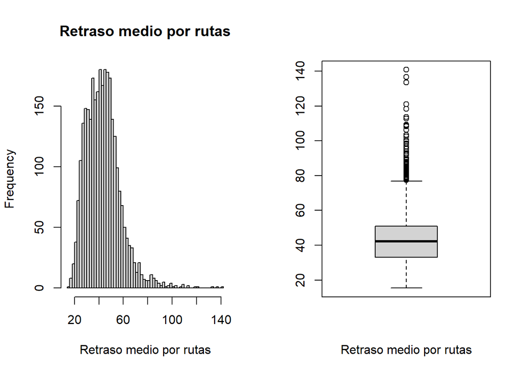

```r
par(mfrow = c(1,2))
hist(resumen_rutas$media_retrasos, 50,  main = "Retraso medio por rutas", xlab = "Retraso medio por rutas")
boxplot(resumen_rutas$media_retrasos, xlab = "Retraso medio por rutas")
```

Visualizando el histograma y el box-whisker podemos observar que hay bastantes rutas con medias de retraso bastante grandes. Identificamos estas rutas:

```r
max_vals = which(resumen_rutas$media_retrasos > quantile(resumen_rutas$media_retrasos, 0.95))

aer_anom_ruta = resumen_rutas[max_vals, ]
```

Visualizamos antes de proseguir con las rutas anómalas, los aeropuertos que participan en más rutas:

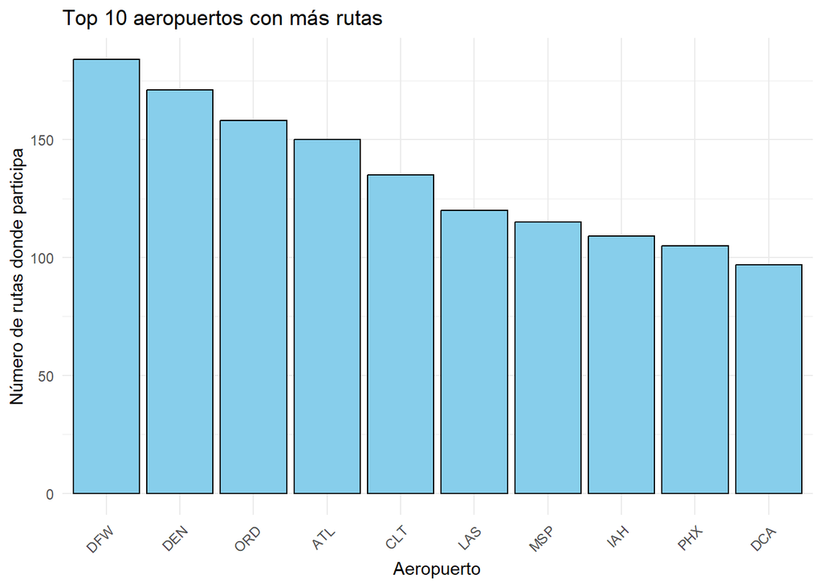

```r
rutas_anonimas_separadas <- resumen_rutas %>%
  separate(RUTA, into = c("origen", "destino"), sep = "-")

aeropuertos <- c(rutas_anonimas_separadas$origen, rutas_anonimas_separadas$destino)

frecuencia_aeropuertos <- table(aeropuertos)

frecuencia_aeropuertos_df <- as.data.frame(frecuencia_aeropuertos)
colnames(frecuencia_aeropuertos_df) <- c("Aeropuerto", "Frecuencia")

frecuencia_aeropuertos_df <- frecuencia_aeropuertos_df %>%
  arrange(desc(Frecuencia))

top_10_aer_rutas <- frecuencia_aeropuertos_df %>%
  slice_head(n = 10)

datos_top_10 <- frecuencia_aeropuertos_df %>%
  filter(Aeropuerto %in% top_10_aer_rutas$Aeropuerto)

datos_top_10$Aeropuerto <- factor(datos_top_10$Aeropuerto, levels = top_10_aer_rutas$Aeropuerto)

ggplot(datos_top_10, aes(x = Aeropuerto, y = Frecuencia)) +
  geom_bar(stat = "identity", fill = "skyblue", color = "black") +
  labs(x = "Aeropuerto", y = "Número de rutas donde participa", title = "Top 10 aeropuertos con más rutas") +
  theme_minimal() +
  theme(axis.text.x = element_text(angle = 45, hjust = 1))
```

Podemos observar que muchos de los aeropuertos que participan en más rutas, pertenecen al top10 aeropuertos con más vuelos.

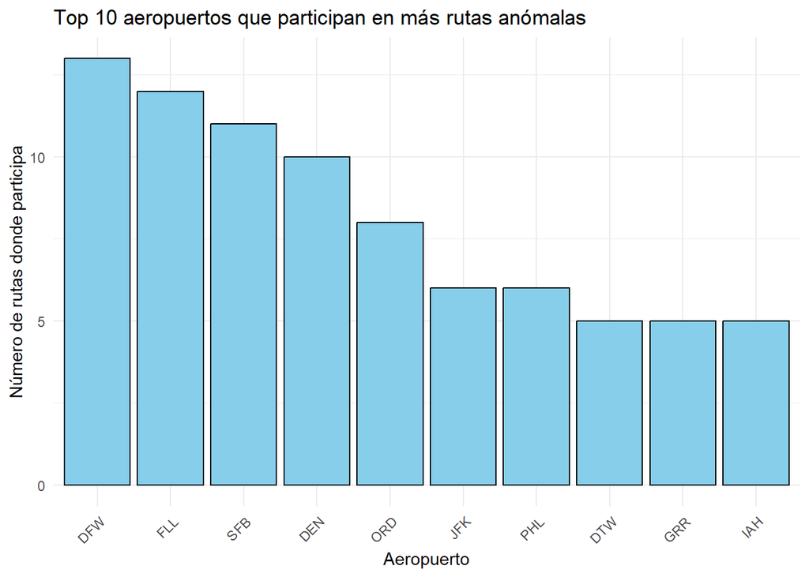

```r
rutas_anonimas_separadas <- aer_anom_ruta %>%
  separate(RUTA, into = c("origen", "destino"), sep = "-")

aeropuertos <- c(rutas_anonimas_separadas$origen, rutas_anonimas_separadas$destino)

frecuencia_aeropuertos <- table(aeropuertos)

frecuencia_aeropuertos_df <- as.data.frame(frecuencia_aeropuertos)
colnames(frecuencia_aeropuertos_df) <- c("Aeropuerto", "Frecuencia")

frecuencia_aeropuertos_df <- frecuencia_aeropuertos_df %>%
  arrange(desc(Frecuencia))

top_10_aer_rutas <- frecuencia_aeropuertos_df %>%
  slice_head(n = 10)

datos_top_10 <- frecuencia_aeropuertos_df %>%
  filter(Aeropuerto %in% top_10_aer_rutas$Aeropuerto)

datos_top_10$Aeropuerto <- factor(datos_top_10$Aeropuerto, levels = top_10_aer_rutas$Aeropuerto)

ggplot(datos_top_10, aes(x = Aeropuerto, y = Frecuencia)) +
  geom_bar(stat = "identity", fill = "skyblue", color = "black") +
  labs(x = "Aeropuerto", y = "Número de rutas donde participa", title = "Top 10 aeropuertos que participan en más rutas anómalas") +
  theme_minimal() +
  theme(axis.text.x = element_text(angle = 45, hjust = 1))
```

Al mostrar quiénes son los aeropuertos qué participan en más rutas anómalas, observamos que muchos de ellos aparecían antes cómo aeropuertos que participaban en mayor número de rutas. Ahora estudiaremos cuáles son las causas de retraso más frecuentes para las rutas anómalas y las compararemos con el resto de rutas:

```r
df_anom_rutas <- df %>%
  filter(RUTA %in% aer_anom_ruta$RUTA)
```

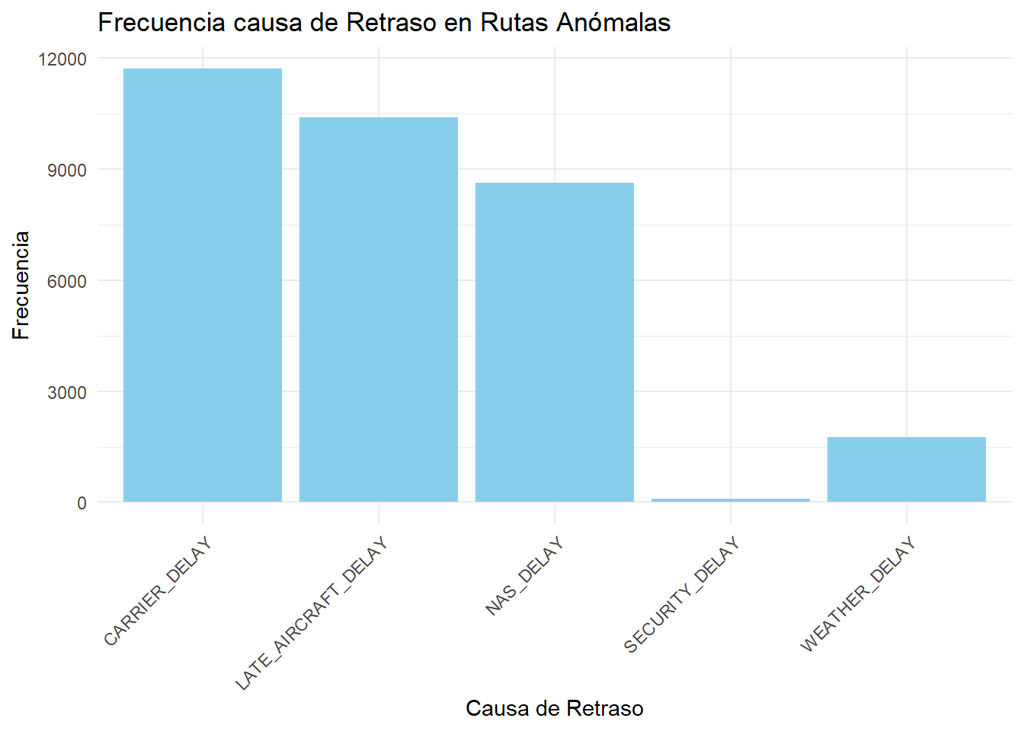

```r
causas_retraso <- df_anom_rutas %>%
  dplyr::summarise(
    CARRIER_DELAY = sum(!is.na(CARRIER_DELAY) & CARRIER_DELAY > 0),
    WEATHER_DELAY = sum(!is.na(WEATHER_DELAY) & WEATHER_DELAY > 0),
    NAS_DELAY = sum(!is.na(NAS_DELAY) & NAS_DELAY > 0),
    SECURITY_DELAY = sum(!is.na(SECURITY_DELAY) & SECURITY_DELAY > 0),
    LATE_AIRCRAFT_DELAY = sum(!is.na(LATE_AIRCRAFT_DELAY) & LATE_AIRCRAFT_DELAY > 0)
  )

causas_retraso_long <- causas_retraso %>%
  pivot_longer(everything(), names_to = "causa", values_to = "frecuencia")

ggplot(causas_retraso_long, aes(x = causa, y = frecuencia)) +
  geom_bar(stat = "identity", fill = "skyblue") +
  labs(title = "Frecuencia causa de Retraso en Rutas Anómalas",
       x = "Causa de Retraso", y = "Frecuencia") +
  theme_minimal() +
  theme(axis.text.x = element_text(angle = 45, hjust = 1))
```

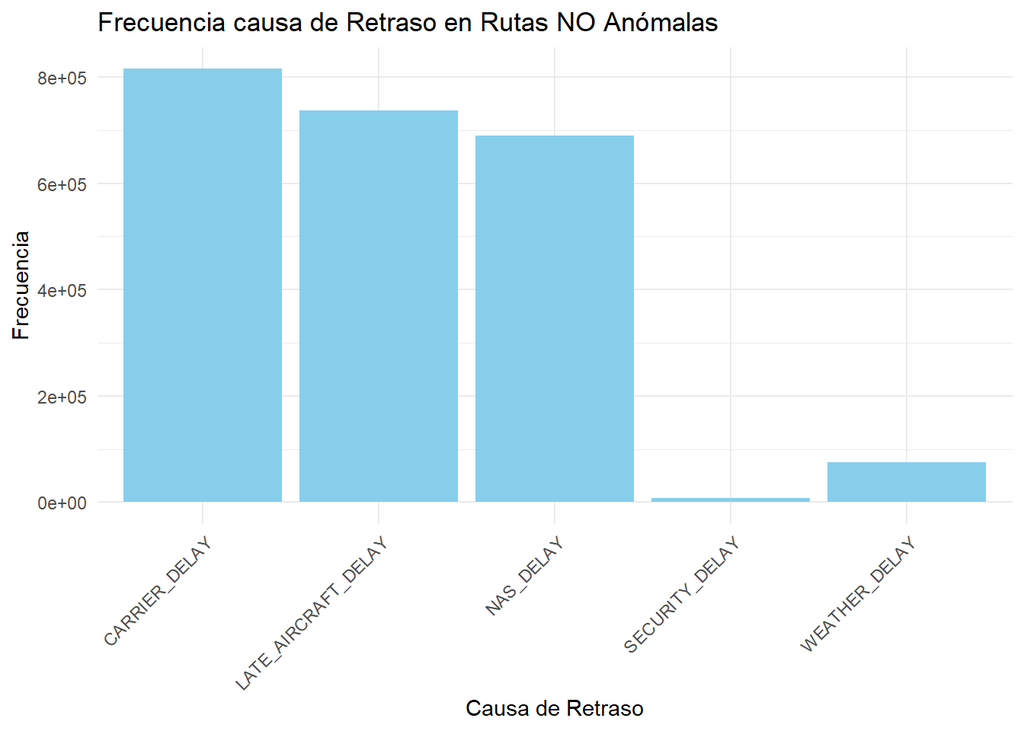

```r
rutas_norm <- anti_join(resumen_rutas, aer_anom_ruta, by = "RUTA")
rutas_norm_df <- df %>%
  filter(RUTA %in% rutas_norm$RUTA)
causas_retraso <- rutas_norm_df %>%
  dplyr::summarise(
    CARRIER_DELAY = sum(!is.na(CARRIER_DELAY) & CARRIER_DELAY > 0),
    WEATHER_DELAY = sum(!is.na(WEATHER_DELAY) & WEATHER_DELAY > 0),
    NAS_DELAY = sum(!is.na(NAS_DELAY) & NAS_DELAY > 0),
    SECURITY_DELAY = sum(!is.na(SECURITY_DELAY) & SECURITY_DELAY > 0),
    LATE_AIRCRAFT_DELAY = sum(!is.na(LATE_AIRCRAFT_DELAY) & LATE_AIRCRAFT_DELAY > 0)
  )

causas_retraso_long <- causas_retraso %>%
  pivot_longer(everything(), names_to = "causa", values_to = "frecuencia")

ggplot(causas_retraso_long, aes(x = causa, y = frecuencia)) +
  geom_bar(stat = "identity", fill = "skyblue") +
  labs(title = "Frecuencia causa de Retraso en Rutas NO Anómalas",
       x = "Causa de Retraso", y = "Frecuencia") +
  theme_minimal() +
  theme(axis.text.x = element_text(angle = 45, hjust = 1))
```

Observamos en ambos casos la misma tendencia. La causa más frecuente de retraso siempre es CARRIER_DELAY(retraso de la compañía). Estudiaremos ahora algunas correlaciones entre variables de las rutas:

```r
cor.test(resumen_rutas$distancia, resumen_rutas$media_retrasos)
```

```
##
##  Pearson's product-moment correlation
##
## data:  resumen_rutas$distancia and resumen_rutas$media_retrasos
## t = -2.6181, df = 2992, p-value = 0.008887
## alternative hypothesis: true correlation is not equal to 0
## 95 percent confidence interval:
##  -0.08348808 -0.01200693
## sample estimates:
##         cor
## -0.04780871
```

En primer lugar, observamos que la correlación entre distancia recorrida y la media en el retraso, a pesar de ser esta significativa(p-valor<0.05), es muy débil ya que, el coef. de correlación de Pearson es cercano a 0.

```r
cor.test(resumen_rutas$distancia, resumen_rutas$prob_retraso)
```

```
##
##  Pearson's product-moment correlation
##
## data:  resumen_rutas$distancia and resumen_rutas$prob_retraso
## t = 17.048, df = 2992, p-value < 2.2e-16
## alternative hypothesis: true correlation is not equal to 0
## 95 percent confidence interval:
##  0.2645557 0.3298644
## sample estimates:
##       cor
## 0.2975581
```

Siguiendo con la distancia, la correlación entre la distancia que se recorre en una ruta y la probabilidad de retraso es moderada positiva y además significativa. Por tanto, podemos asumir que cuánto mayor es la distancia la probabilidad de retraso en una ruta tenderá a aumentar ligeramente.

Comprobamos si ocurre lo mismo que sucedía en los aeropuertos con el número total de vuelos y la probabilidad de retraso:

```r
cor.test(resumen_rutas$total_vuelos, resumen_rutas$prob_retraso)
```

```
##
##  Pearson's product-moment correlation
##
## data:  resumen_rutas$total_vuelos and resumen_rutas$prob_retraso
## t = -1.2291, df = 2992, p-value = 0.2191
## alternative hypothesis: true correlation is not equal to 0
## 95 percent confidence interval:
##  -0.05823945  0.01336913
## sample estimates:
##         cor
## -0.02246398
```

Para las rutas no encontramos una relación significativa entre estas variables (p-valor>0.05), por lo que podemos decir que no existe relación entre el total de vuelos en una ruta y su probabilidad de retraso.

Planteamos ahora si existe relación entre el total de vuelos y la media de retraso de una ruta:

```r
cor.test(resumen_rutas$total_vuelos, resumen_rutas$media_retrasos)
```

```
##
##  Pearson's product-moment correlation
##
## data:  resumen_rutas$total_vuelos and resumen_rutas$media_retrasos
## t = -4.6489, df = 2992, p-value = 3.482e-06
## alternative hypothesis: true correlation is not equal to 0
## 95 percent confidence interval:
##  -0.12014250 -0.04901095
## sample estimates:
##         cor
## -0.08468462
```

Obtenemos una relación estadísticamente significativa(p-valor<0.05). Sin embargo, está relación es muy débil y no nos aporta mucha información.

Por último, estudiamos la relación entre el total de vuelos y la distancia:

```r
cor.test(resumen_rutas$total_vuelos, resumen_rutas$distancia)
```

```
##
##  Pearson's product-moment correlation
##
## data:  resumen_rutas$total_vuelos and resumen_rutas$distancia
## t = -7.052, df = 2992, p-value = 2.181e-12
## alternative hypothesis: true correlation is not equal to 0
## 95 percent confidence interval:
##  -0.16294097 -0.09246615
## sample estimates:
##       cor
## -0.127865
```

```r
resumen_rutas %>%
  arrange(desc(total_vuelos)) %>%
  head(5)
```

```
## # A tibble: 5 × 10
##   RUTA    total_vuelos vuelos_retrasados vuelos_adelantados vuelos_puntuales
##   <chr>          <int>             <int>              <int>            <int>
## 1 HNL-OGG        24886             11596              12370              920
## 2 LAX-SFO        23202              8946              13805              451
## 3 LAS-LAX        20896              9454              11032              410
## 4 JFK-LAX        19879              7197              12443              239
## 5 LGA-ORD        19255              6268              12731              256
## # ℹ 5 more variables: prob_retraso <dbl>, media_retrasos <dbl>,
## #   adelanto_medio <dbl>, distancia <int>, indice_rendimiento <dbl>
```

## 3.1 Estudio de ciertas rutas.

Vamos a elegir ciertas rutas para estudiarlas: -En primer lugar, la ruta HNL-OGG, que es la más frecuente en todo 2023. -En segundo lugar, rutas del aeropuerto ATL que es el aeropuerto con más vuelos, y determinaremos la peores rutas y las mejores rutas donde participa este aeropuerto. -En tercer lugar, las rutas relacionadas con el aeropuerto de FAI, que es un aeropuerto con un buen indice de rendimiento y con un número considerable de vuelos. Veremos si actua de la misma manera en todas sus rutas o cambia su comportamiento dependiendo del otro aeropuerto con el que forma la ruta. -En último lugar, las rutas relacionadas con el aeropuerto FLL, un aeropuerto con muy mal indice de rendimiento.

Comenzamos con el estudio de la ruta HNL-OGG. Podemos destacar que los dos aerpuertos que forman la ruta son pertenecientes a Hawai:

```r
df_HNL_OGG <- df %>%
  filter(RUTA == "HNL-OGG")
```

```r
num_dias_mes=c(31,28,31,30,31,30,31,31,30,31,30,31)
```

Representamos gráficamente la evolución de la media diaria del número vuelos para cada mes, de la media diaria del número de vuelos retrasados para cada mes y de la media de retraso en los vuelos retrasados para cada mes:

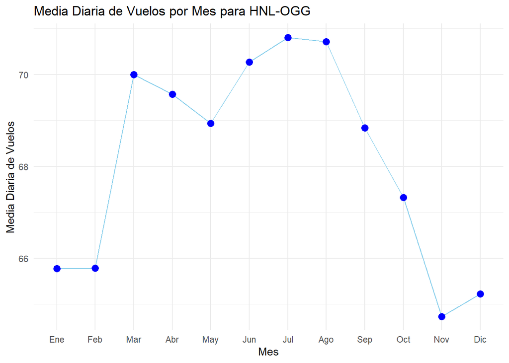

```r
resumen <- df_HNL_OGG %>%
  group_by( MONTH) %>%
  dplyr::summarise(num_vuelos = n())
resumen <- resumen %>%
  mutate(num_dias = num_dias_mes[as.integer(MONTH)])
resumen <- resumen %>%
  mutate(media_diaria = num_vuelos / num_dias)
ggplot(resumen, aes(x = factor(MONTH), y = media_diaria, group = 1)) +
  geom_line(color = "skyblue") +
  geom_point(color = "blue", size = 3) +
  labs(title =("Media Diaria de Vuelos por Mes para HNL-OGG" ),
       x = "Mes", y = "Media Diaria de Vuelos") +
  scale_x_discrete(labels = c("Ene", "Feb", "Mar", "Abr", "May", "Jun", "Jul", "Ago", "Sep", "Oct", "Nov", "Dic")) +
  theme_minimal()
```

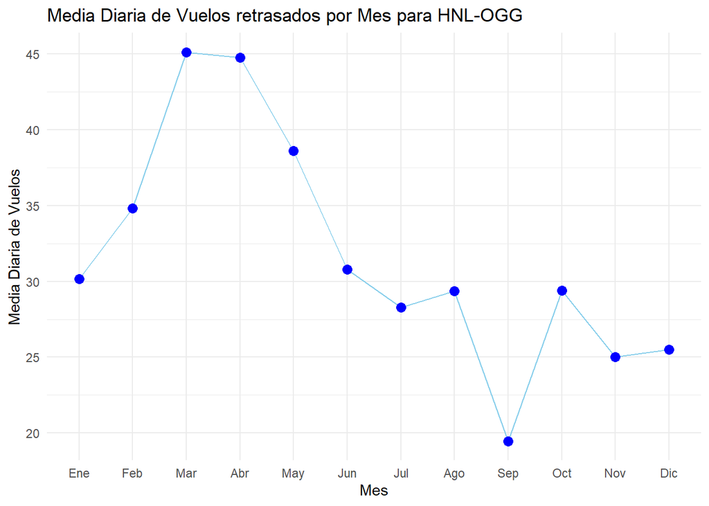

```r
df_HNL_OGG_ret <- df_HNL_OGG %>%
  filter(ARR_DELAY > 0)
resumen <- df_HNL_OGG_ret %>%
  group_by( MONTH) %>%
  dplyr::summarise(num_vuelos = n())
resumen <- resumen %>%
  mutate(num_dias = num_dias_mes[as.integer(MONTH)])
resumen <- resumen %>%
  mutate(media_diaria = num_vuelos / num_dias)
ggplot(resumen, aes(x = factor(MONTH), y = media_diaria, group = 1)) +
  geom_line(color = "skyblue") +
  geom_point(color = "blue", size = 3) +
  labs(title =("Media Diaria de Vuelos retrasados por Mes para HNL-OGG" ),
       x = "Mes", y = "Media Diaria de Vuelos") +
  scale_x_discrete(labels = c("Ene", "Feb", "Mar", "Abr", "May", "Jun", "Jul", "Ago", "Sep", "Oct", "Nov", "Dic")) +
  theme_minimal()
```

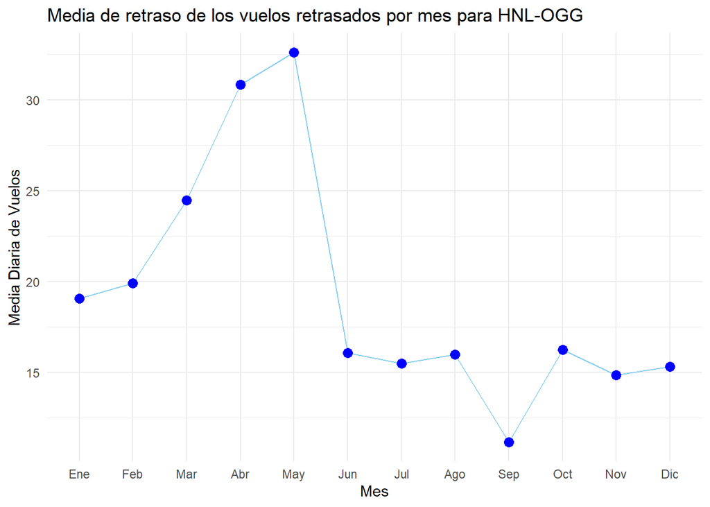

```r
resumen <- df_HNL_OGG %>%
  group_by( MONTH) %>%
  dplyr::summarise(media_retraso=round(sum(ARR_DELAY[ARR_DELAY > 0], na.rm = TRUE) / sum(ARR_DELAY > 0, na.rm=TRUE), 2))

ggplot(resumen, aes(x = factor(MONTH), y = media_retraso, group = 1)) +
  geom_line(color = "skyblue") +
  geom_point(color = "blue", size = 3) +
  labs(title =("Media de retraso de los vuelos retrasados por mes para HNL-OGG" ),
       x = "Mes", y = "Media Diaria de Vuelos") +
  scale_x_discrete(labels = c("Ene", "Feb", "Mar", "Abr", "May", "Jun", "Jul", "Ago", "Sep", "Oct", "Nov", "Dic")) +
  theme_minimal()
```

Nos centramos ahora en las rutas en las que participa el aeropuerto de ATL:

```r
df_ATL <- df %>%
  filter(str_detect(RUTA, "ATL"))
```

```r
resumen_ATL <- df_ATL %>%
  group_by(RUTA) %>%
  dplyr::summarise(
    total_vuelos = n(),
    vuelos_retrasados = sum(ARR_DELAY > 0, na.rm = TRUE),
    vuelos_adelantados = sum(ARR_DELAY < 0, na.rm = TRUE),
    vuelos_puntuales = sum(ARR_DELAY == 0, na.rm = TRUE),
    prob_retraso = round(vuelos_retrasados / total_vuelos, 2),
    media_retrasos = round(sum(ARR_DELAY[ARR_DELAY > 0], na.rm = TRUE) / sum(ARR_DELAY > 0, na.rm = TRUE), 2),
    adelanto_medio = -1*round(sum(ARR_DELAY[ARR_DELAY < 0], na.rm = TRUE) / sum(ARR_DELAY < 0, na.rm = TRUE), 2),
    distancia=first(DISTANCE),
    indice_rendimiento=round(prob_retraso*media_retrasos,2)
  )
```

Visualizamos las mejores y peores rutas en las que participa este aeropuerto:

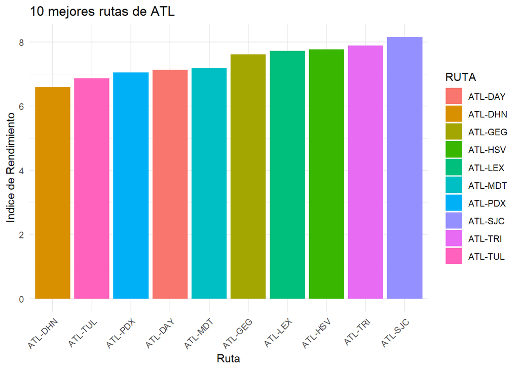

```r
resumen_ATL %>%
  filter(total_vuelos > 100) %>%
  arrange(indice_rendimiento) %>%
  head(10) %>%
  ggplot(aes(x = reorder(RUTA, indice_rendimiento), y = indice_rendimiento, fill = RUTA)) +
  geom_bar(stat = "identity") +
  labs(title = "10 mejores rutas de ATL",
       x = "Ruta", y = "Indice de Rendimiento") +
  theme_minimal() +
  theme(axis.text.x = element_text(angle = 45, hjust = 1))
```

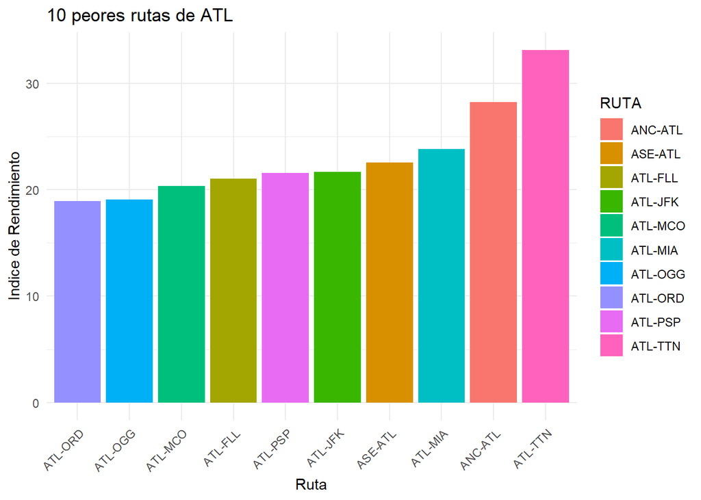

```r
resumen_ATL %>%
  filter(total_vuelos > 100) %>%
  arrange(desc(indice_rendimiento)) %>%
  head(10) %>%
  ggplot(aes(x = reorder(RUTA, indice_rendimiento), y = indice_rendimiento, fill = RUTA)) +
  geom_bar(stat = "identity") +
  labs(title = "10 peores rutas de ATL",
       x = "Ruta", y = "Indice de Rendimiento") +
  theme_minimal() +
  theme(axis.text.x = element_text(angle = 45, hjust = 1))
```

Tras visualizarlas, intentamos determinar si la región o el cluster al que pertenecen guardan algún tipo de relación con el rendimiento de la ruta:

```r
mejores_atl=c("DHN","TUL","PDX","DAY","MDT","GEG","LEX","HSV","TRI","SJC")
peores_atl=c("JFK","ASE","MIA","ANC","TTN","ORD","OGG","MCO","FLL","PSP")
```

```r
mejores_atl_df <- data.frame(DEST = mejores_atl)
peores_atl_df <- data.frame(DEST = peores_atl)


mejores_atl_info <- mejores_atl_df %>%
  left_join(aeropuertos_destino, by = "DEST")

peores_atl_info <- peores_atl_df %>%
  left_join(aeropuertos_destino, by = "DEST")

mejores_atl_info <- mejores_atl_info %>%
  rename(Aeropuerto = DEST)

peores_atl_info <- peores_atl_info %>%
  rename(Aeropuerto = DEST)
```

```r
mejores_atl_info <- mejores_atl_info %>%
  mutate(region = sapply(estado, asignar_region))

peores_atl_info <- peores_atl_info %>%
  mutate(region = sapply(estado, asignar_region))
```

```r
kable(mejores_atl_info)
```

| Aeropuerto | total_vuelos | vuelos_retrasados | vuelos_adelantados | vuelos_puntuales | prob_retraso | retraso_medio | adelanto_medio | estado | indice_actuacion_d | indice_categoria | region |
| --- | --- | --- | --- | --- | --- | --- | --- | --- | --- | --- | --- |
| DHN | 728 | 133 | 583 | 12 | 0.18 | 32.70 | 12.58 | Alabama | 5.8860 | Muy Bueno | Sur |
| TUL | 17791 | 6729 | 10678 | 384 | 0.38 | 37.20 | 12.11 | Oklahoma | 14.1360 | Regular | Sur |
| PDX | 66466 | 23052 | 42008 | 1406 | 0.35 | 32.05 | 13.06 | Oregon | 11.2175 | Bueno | Oeste |
| DAY | 9685 | 3177 | 6326 | 182 | 0.33 | 48.92 | 13.45 | Ohio | 16.1436 | Malo | Mediooeste |
| MDT | 8172 | 2628 | 5412 | 132 | 0.32 | 41.69 | 13.54 | Pennsylvania | 13.3408 | Bueno | Noreste |
| GEG | 20647 | 7453 | 12709 | 485 | 0.36 | 30.63 | 11.48 | Washington | 11.0268 | Bueno | Oeste |
| LEX | 8732 | 2691 | 5905 | 136 | 0.31 | 41.92 | 12.76 | Kentucky | 12.9952 | Bueno | Sur |
| HSV | 10476 | 3245 | 7024 | 207 | 0.31 | 40.97 | 12.77 | Alabama | 12.7007 | Bueno | Sur |
| TRI | 4009 | 1015 | 2943 | 51 | 0.25 | 38.11 | 13.31 | Tennessee | 9.5275 | Muy Bueno | Sur |
| SJC | 52591 | 19068 | 32456 | 1067 | 0.36 | 27.88 | 11.70 | California | 10.0368 | Muy Bueno | Oeste |

Para las mejores rutas en las que participa el aeropuerto de ATL podemos destacar que la región más frecuente es la Sur con 5 aeropuertos seguida de la Oeste con 3. Tampoco observamos una región predominante.

```r
kable(peores_atl_info)
```

| Aeropuerto | total_vuelos | vuelos_retrasados | vuelos_adelantados | vuelos_puntuales | prob_retraso | retraso_medio | adelanto_medio | estado | indice_actuacion_d | indice_categoria | region |
| --- | --- | --- | --- | --- | --- | --- | --- | --- | --- | --- | --- |
| JFK | 129543 | 49598 | 77969 | 1976 | 0.38 | 54.52 | 16.88 | New York | 20.7176 | Malo | Noreste |
| ASE | 5997 | 2774 | 3105 | 118 | 0.46 | 53.72 | 14.38 | Colorado | 24.7112 | Malo | Oeste |
| MIA | 100967 | 40002 | 59270 | 1695 | 0.40 | 46.45 | 14.50 | Florida | 18.5800 | Malo | Medioatlántica |
| ANC | 21053 | 7655 | 12999 | 399 | 0.36 | 31.14 | 15.49 | Alaska | 11.2104 | Bueno | Oeste |
| TTN | 2165 | 1040 | 1089 | 36 | 0.48 | 54.90 | 13.75 | New Jersey | 26.3520 | Malo | Noreste |
| ORD | 290476 | 100522 | 184980 | 4974 | 0.35 | 48.20 | 15.40 | Illinois | 16.8700 | Malo | Mediooeste |
| OGG | 29656 | 12488 | 16320 | 848 | 0.42 | 24.98 | 11.77 | Hawaii | 10.4916 | Muy Bueno | Oeste |
| MCO | 161373 | 69803 | 88764 | 2806 | 0.43 | 49.40 | 13.93 | Florida | 21.2420 | Malo | Medioatlántica |
| FLL | 87737 | 39134 | 47115 | 1488 | 0.45 | 48.39 | 14.36 | Florida | 21.7755 | Malo | Medioatlántica |
| PSP | 14178 | 5438 | 8408 | 332 | 0.38 | 31.82 | 12.14 | California | 12.0916 | Bueno | Oeste |

Realizando lo mismo que antes pero ahora con los aeropuertos donde ATL rinde peor, tampoco observamos una región predominante. Sin embargo, el estado de Florida aparece 3 veces siendo estas las veces que aparece la región de este estado.

Estudiamos ahora si el cluster al que pertenece el aeropuerto que forma la ruta junto con ATL influye en el rendimiento de la misma:

```r
cluster1_df$Aeropuerto <- rownames(cluster1_df)
cluster2_df$Aeropuerto <- rownames(cluster2_df)
cluster3_df$Aeropuerto <- rownames(cluster3_df)
clus_aer <- bind_rows(cluster1_df, cluster2_df, cluster3_df)
mejores2_atl_info <- mejores_atl_info %>%
  left_join(clus_aer, by = "Aeropuerto")

peores2_atl_info <- peores_atl_info %>%
  left_join(clus_aer, by = "Aeropuerto")
```

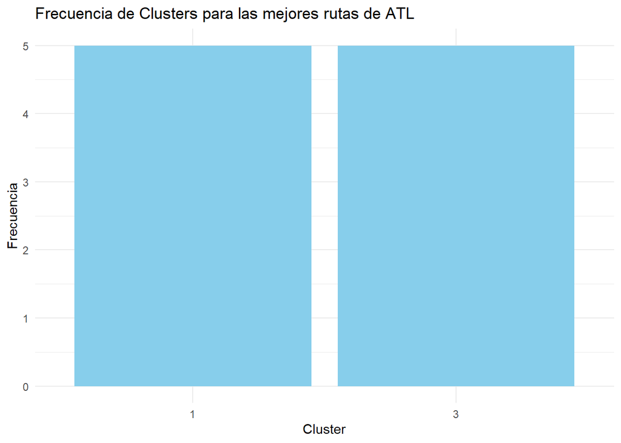

```r
cluster_counts <- mejores2_atl_info %>%
  count(cluster)

# Crear el diagrama de barras
ggplot(cluster_counts, aes(x = factor(cluster), y = n)) +
  geom_bar(stat = "identity", fill = "skyblue") +
  labs(title = "Frecuencia de Clusters para las mejores rutas de ATL",
       x = "Cluster",
       y = "Frecuencia") +
  theme_minimal()
```

Podemos ver que, a pesar de que no observamos una tendencia predominante, parece que el aeropuerto de ATL rinde mejor con aeropuertos con pocos vuelos (característica de los clusters 1 y 3), es decir, ATL tiene mejor rendimiento en sus rutas con aeropuertos pequeños.

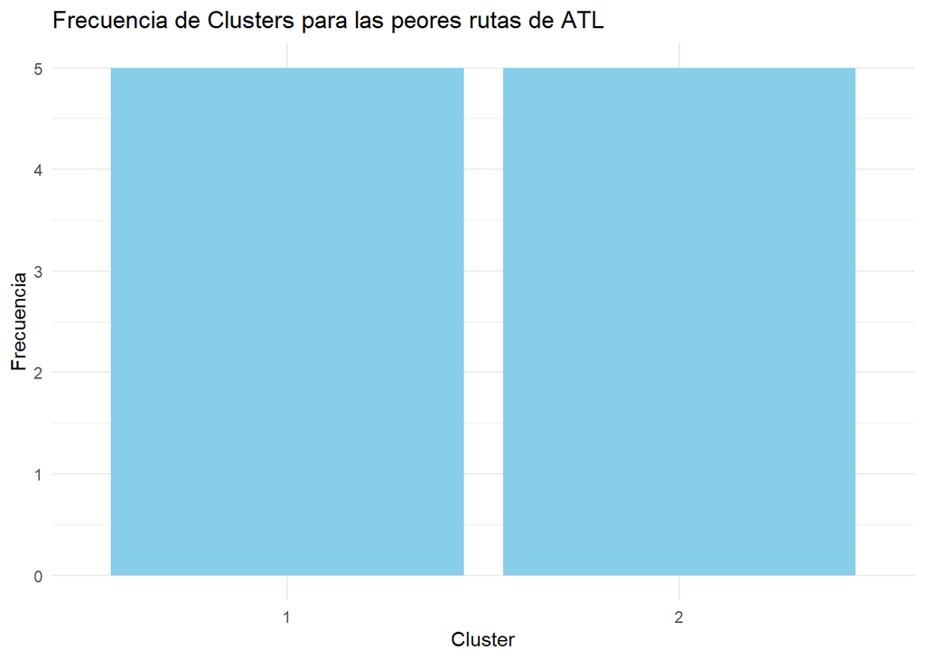

```r
cluster_counts2 <- peores2_atl_info %>%
  count(cluster)

# Crear el diagrama de barras
ggplot(cluster_counts2, aes(x = factor(cluster), y = n)) +
  geom_bar(stat = "identity", fill = "skyblue") +
  labs(title = "Frecuencia de Clusters para las peores rutas de ATL",
       x = "Cluster",
       y = "Frecuencia") +
  theme_minimal()
```

Para las peores rutas en las que participa, no observamos una tendencia clara ya que, el cluster 1 aparecía también antes. Ahora, aparece también el cluster 2 que hacía referencia a aeropuertos grandes (gran número de vuelos). La única característica común entre estos clusters es que están formados por aeropuertos con una probabilidad de retraso notable. Por tanto, puede que ATL rinda mal con aeropuertos con probabilidades de retraso considerables.

Nos centramos ahira en las rutas del aeropuerto de FAI, el cual es un aeropuerto con muy buen índice de actuación y un número considerable de vuelos:

```r
df_FAI <- df %>%
  filter(str_detect(RUTA, "FAI"))
```

```r
resumen_FAI <- df_FAI %>%
  group_by(RUTA) %>%
  dplyr::summarise(
    total_vuelos = n(),
    vuelos_retrasados = sum(ARR_DELAY > 0, na.rm = TRUE),
    vuelos_adelantados = sum(ARR_DELAY < 0, na.rm = TRUE),
    vuelos_puntuales = sum(ARR_DELAY == 0, na.rm = TRUE),
    prob_retraso = round(vuelos_retrasados / total_vuelos, 2),
    media_retrasos = round(sum(ARR_DELAY[ARR_DELAY > 0], na.rm = TRUE) / sum(ARR_DELAY > 0, na.rm = TRUE), 2),
    adelanto_medio = -1*round(sum(ARR_DELAY[ARR_DELAY < 0], na.rm = TRUE) / sum(ARR_DELAY < 0, na.rm = TRUE), 2),
    distancia=first(DISTANCE),
    indice_rendimiento=round(prob_retraso*media_retrasos,2)
  )
print(resumen_FAI)
```

```
## # A tibble: 4 × 10
##   RUTA    total_vuelos vuelos_retrasados vuelos_adelantados vuelos_puntuales
##   <chr>          <int>             <int>              <int>            <int>
## 1 ANC-FAI         5282              1685               3471              126
## 2 FAI-MSP          183                43                132                8
## 3 FAI-ORD          215                53                157                5
## 4 FAI-SEA         4322              1757               2496               69
## # ℹ 5 more variables: prob_retraso <dbl>, media_retrasos <dbl>,
## #   adelanto_medio <dbl>, distancia <int>, indice_rendimiento <dbl>
```

Observamos que este aeropuerto participa únicamente en 4 rutas. Estudiaremos el comportamiento de las rutas ANC-FAI y FAI-SEA ya que poseen bastantes más vuelos que las dos restantes:

```r
df_FAI_ANC<-df %>%
  filter(RUTA == "ANC-FAI")
```

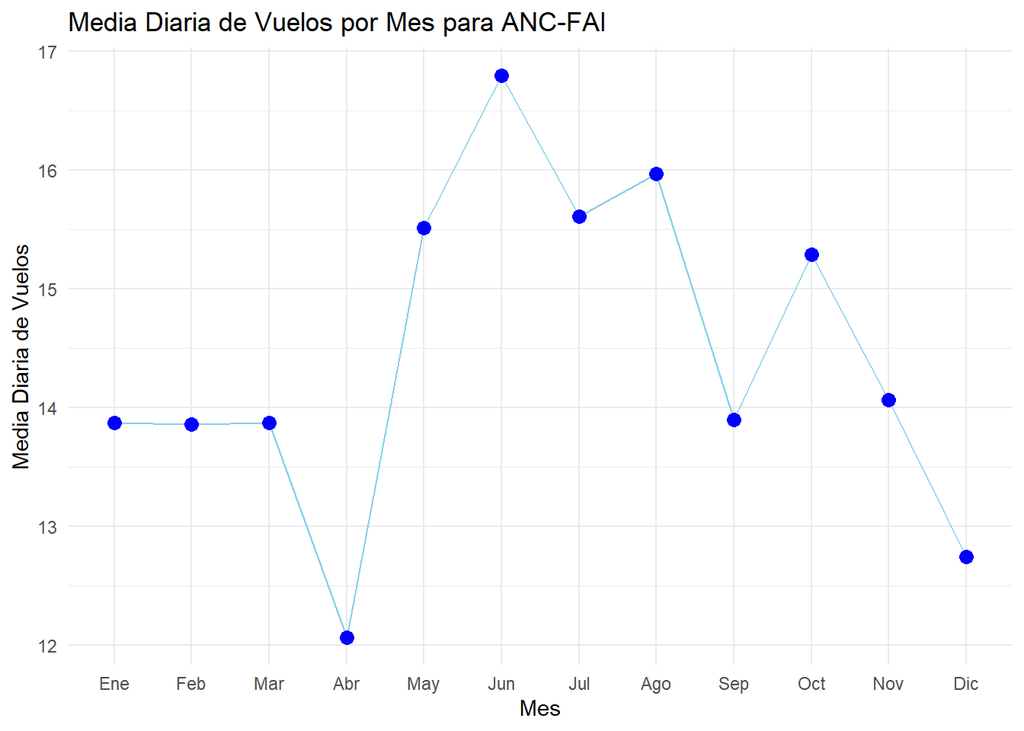

```r
resumen <- df_FAI_ANC %>%
  group_by( MONTH) %>%
  dplyr::summarise(num_vuelos = n())
resumen <- resumen %>%
  mutate(num_dias = num_dias_mes[as.integer(MONTH)])
resumen <- resumen %>%
  mutate(media_diaria = num_vuelos / num_dias)
ggplot(resumen, aes(x = factor(MONTH), y = media_diaria, group = 1)) +
  geom_line(color = "skyblue") +
  geom_point(color = "blue", size = 3) +
  labs(title =("Media Diaria de Vuelos por Mes para ANC-FAI" ),
       x = "Mes", y = "Media Diaria de Vuelos") +
  scale_x_discrete(labels = c("Ene", "Feb", "Mar", "Abr", "May", "Jun", "Jul", "Ago", "Sep", "Oct", "Nov", "Dic")) +
  theme_minimal()
```

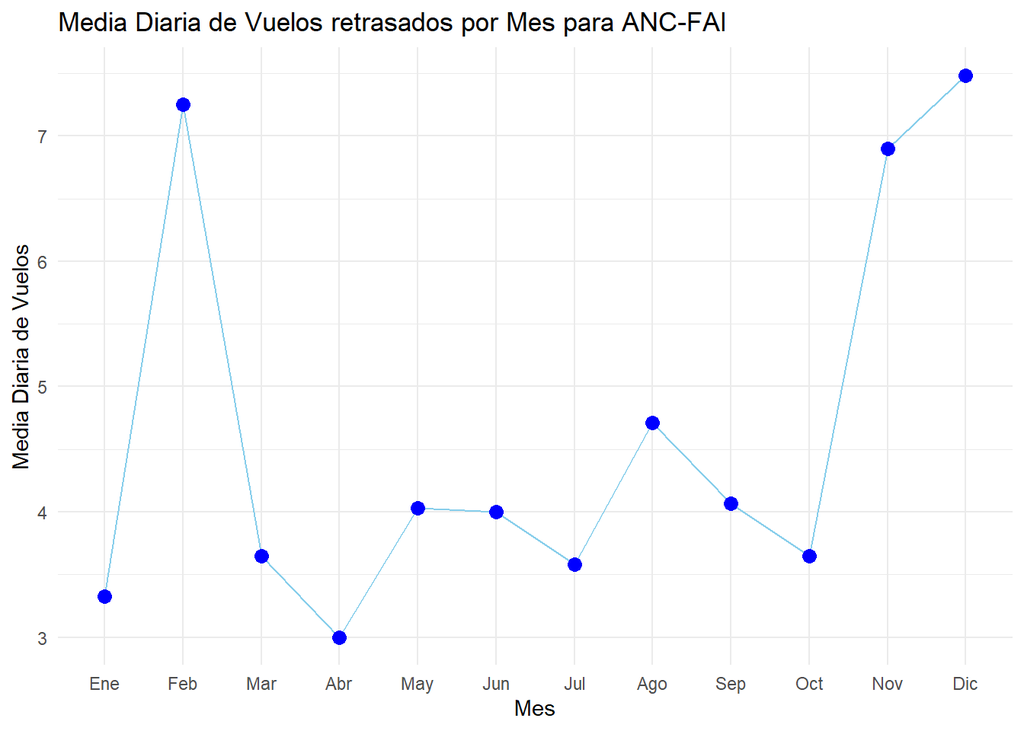

```r
df_FAI_ANC_ret <- df_FAI_ANC %>%
  filter(ARR_DELAY > 0)
resumen <- df_FAI_ANC_ret %>%
  group_by( MONTH) %>%
  dplyr::summarise(num_vuelos = n())
resumen <- resumen %>%
  mutate(num_dias = num_dias_mes[as.integer(MONTH)])
resumen <- resumen %>%
  mutate(media_diaria = num_vuelos / num_dias)
ggplot(resumen, aes(x = factor(MONTH), y = media_diaria, group = 1)) +
  geom_line(color = "skyblue") +
  geom_point(color = "blue", size = 3) +
  labs(title =("Media Diaria de Vuelos retrasados por Mes para ANC-FAI" ),
       x = "Mes", y = "Media Diaria de Vuelos") +
  scale_x_discrete(labels = c("Ene", "Feb", "Mar", "Abr", "May", "Jun", "Jul", "Ago", "Sep", "Oct", "Nov", "Dic")) +
  theme_minimal()
```

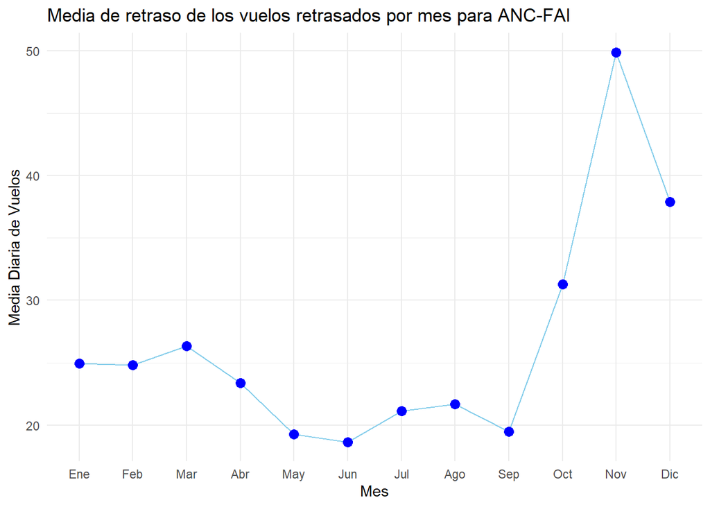

```r
resumen <- df_FAI_ANC %>%
  group_by( MONTH) %>%
  dplyr::summarise(media_retraso=round(sum(ARR_DELAY[ARR_DELAY > 0], na.rm = TRUE) / sum(ARR_DELAY > 0, na.rm=TRUE), 2))
ggplot(resumen, aes(x = factor(MONTH), y = media_retraso, group = 1)) +
  geom_line(color = "skyblue") +
  geom_point(color = "blue", size = 3) +
  labs(title =("Media de retraso de los vuelos retrasados por mes para ANC-FAI" ),
       x = "Mes", y = "Media Diaria de Vuelos") +
  scale_x_discrete(labels = c("Ene", "Feb", "Mar", "Abr", "May", "Jun", "Jul", "Ago", "Sep", "Oct", "Nov", "Dic")) +
  theme_minimal()
```

Para la ruta ANC-FAI no observamos un comportamiento claro en relación a la media de vuelos diaria con los retrasos ya que cuando tiene más vuelos se retrasa menos y tiene menos vuelos retrasados pero su comportomiento en los meses con pocos vuelos es cambiante. Por ejemplo, en los 3 primeros meses del año posee una media diaria de vuelos similar pero es en febrero donde observamos un mayor número de vuelos retrasados.

Pasamos a estudiar la ruta FAI-SEA:

```r
df_FAI_SEA<-df %>%
  filter(RUTA == "FAI-SEA")
```

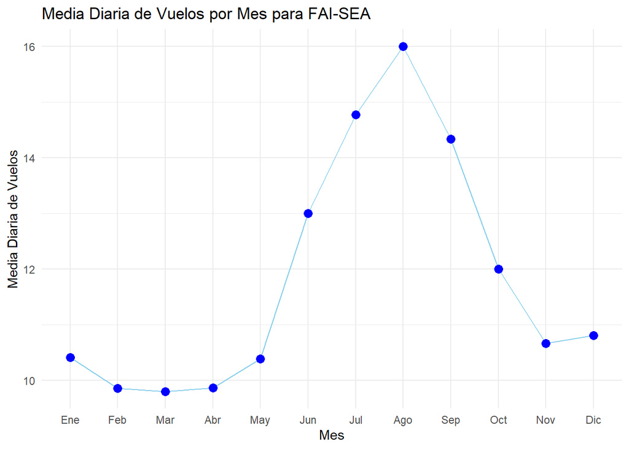

```r
resumen <- df_FAI_SEA %>%
  group_by( MONTH) %>%
  dplyr::summarise(num_vuelos = n())
resumen <- resumen %>%
  mutate(num_dias = num_dias_mes[as.integer(MONTH)])
resumen <- resumen %>%
  mutate(media_diaria = num_vuelos / num_dias)
ggplot(resumen, aes(x = factor(MONTH), y = media_diaria, group = 1)) +
  geom_line(color = "skyblue") +
  geom_point(color = "blue", size = 3) +
  labs(title =("Media Diaria de Vuelos por Mes para FAI-SEA" ),
       x = "Mes", y = "Media Diaria de Vuelos") +
  scale_x_discrete(labels = c("Ene", "Feb", "Mar", "Abr", "May", "Jun", "Jul", "Ago", "Sep", "Oct", "Nov", "Dic")) +
  theme_minimal()
```

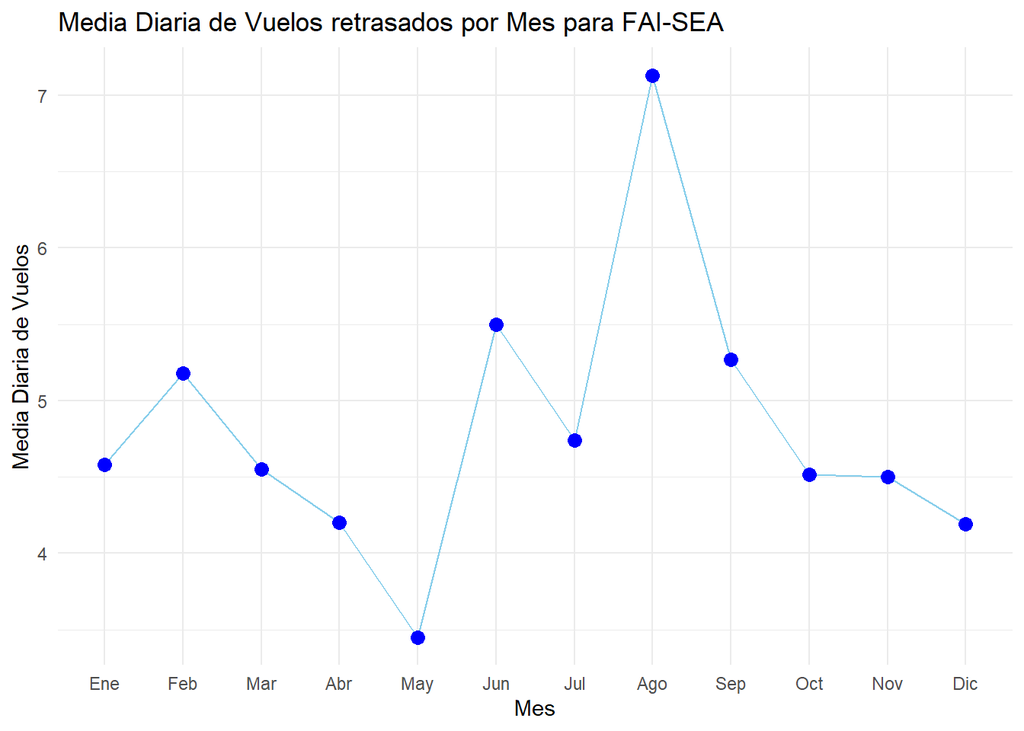

```r
df_FAI_SEA_ret <- df_FAI_SEA %>%
  filter(ARR_DELAY > 0)
resumen <- df_FAI_SEA_ret %>%
  group_by( MONTH) %>%
  dplyr::summarise(num_vuelos = n())
resumen <- resumen %>%
  mutate(num_dias = num_dias_mes[as.integer(MONTH)])
resumen <- resumen %>%
  mutate(media_diaria = num_vuelos / num_dias)
ggplot(resumen, aes(x = factor(MONTH), y = media_diaria, group = 1)) +
  geom_line(color = "skyblue") +
  geom_point(color = "blue", size = 3) +
  labs(title =("Media Diaria de Vuelos retrasados por Mes para FAI-SEA" ),
       x = "Mes", y = "Media Diaria de Vuelos") +
  scale_x_discrete(labels = c("Ene", "Feb", "Mar", "Abr", "May", "Jun", "Jul", "Ago", "Sep", "Oct", "Nov", "Dic")) +
  theme_minimal()
```

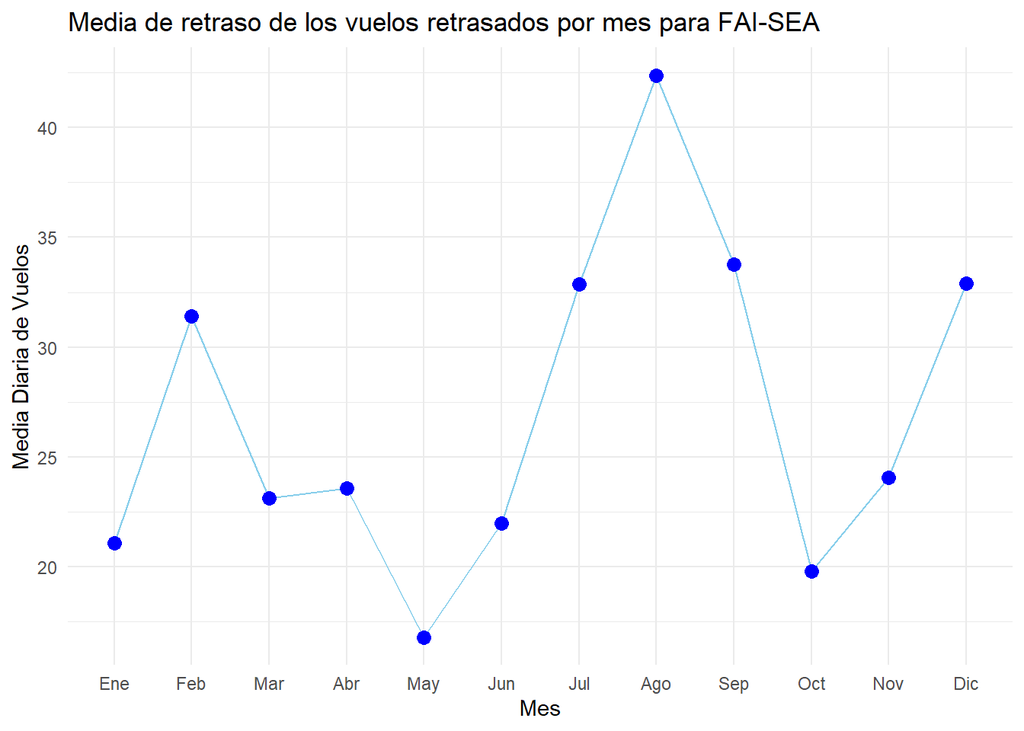

```r
resumen <- df_FAI_SEA %>%
  group_by( MONTH) %>%
  dplyr::summarise(media_retraso=round(sum(ARR_DELAY[ARR_DELAY > 0], na.rm = TRUE) / sum(ARR_DELAY > 0, na.rm=TRUE), 2))
ggplot(resumen, aes(x = factor(MONTH), y = media_retraso, group = 1)) +
  geom_line(color = "skyblue") +
  geom_point(color = "blue", size = 3) +
  labs(title =("Media de retraso de los vuelos retrasados por mes para FAI-SEA" ),
       x = "Mes", y = "Media Diaria de Vuelos") +
  scale_x_discrete(labels = c("Ene", "Feb", "Mar", "Abr", "May", "Jun", "Jul", "Ago", "Sep", "Oct", "Nov", "Dic")) +
  theme_minimal()
```

En esta ruta, parecen seguir tendencias similares el comportamiento del número de vuelos, número de vuelos retrasados y la media en los retrasos. Conforme más vuelos tiene esta ruta parece que muchos se retrasan y además, los retrasos son más prolongados.

Por último estudiamos las rutas del aeropuerto FLL.

```r
df_FLL <- df %>%
  filter(str_detect(RUTA, "FLL"))
```

```r
resumen_FLL <- df_FLL %>%
  group_by(RUTA) %>%
  dplyr::summarise(
    total_vuelos = n(),
    vuelos_retrasados = sum(ARR_DELAY > 0, na.rm = TRUE),
    vuelos_adelantados = sum(ARR_DELAY < 0, na.rm = TRUE),
    vuelos_puntuales = sum(ARR_DELAY == 0, na.rm = TRUE),
    prob_retraso = round(vuelos_retrasados / total_vuelos, 2),
    media_retrasos = round(sum(ARR_DELAY[ARR_DELAY > 0], na.rm = TRUE) / sum(ARR_DELAY > 0, na.rm = TRUE), 2),
    adelanto_medio = -1*round(sum(ARR_DELAY[ARR_DELAY < 0], na.rm = TRUE) / sum(ARR_DELAY < 0, na.rm = TRUE), 2),
    distancia=first(DISTANCE),
    indice_rendimiento=round(prob_retraso*media_retrasos,2)
  )
```

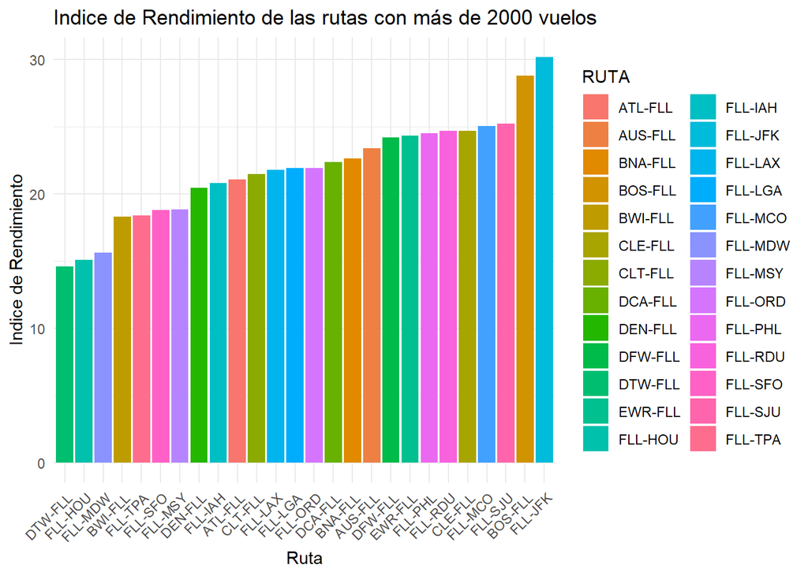

```r
resumen_FLL %>%
  filter(total_vuelos > 2000) %>%
  ggplot(aes(x = reorder(RUTA, indice_rendimiento), y = indice_rendimiento, fill = RUTA)) +
  geom_bar(stat = "identity") +
  labs(title = "Indice de Rendimiento de las rutas con más de 2000 vuelos",
       x = "Ruta", y = "Indice de Rendimiento") +
  theme_minimal() +
  theme(axis.text.x = element_text(angle = 45, hjust = 1))
```

Sabemos que este aeropuerto tenía un mal índice de actuación tanto en el origen como en el destino por lo que consideramos que sería interesante estudiar sus rutas. Nos centramos en su mejor ruta y peor en cuánto a índice:

```r
df_DTW_FLL <- df %>%
  filter(RUTA == "DTW-FLL")
```

```r
resumen_DTW_FLL <- df_DTW_FLL %>%
  group_by(NOMBRE_COMP) %>%
  dplyr::summarise(
    total_vuelos = n(),
    vuelos_retrasados = sum(ARR_DELAY > 0, na.rm = TRUE),
    vuelos_adelantados = sum(ARR_DELAY < 0, na.rm = TRUE),
    vuelos_puntuales = sum(ARR_DELAY == 0, na.rm = TRUE),
    prob_retraso = round(vuelos_retrasados / total_vuelos, 2),
    media_retrasos = round(sum(ARR_DELAY[ARR_DELAY > 0], na.rm = TRUE) / sum(ARR_DELAY > 0, na.rm = TRUE), 2),
    adelanto_medio = -1*round(sum(ARR_DELAY[ARR_DELAY < 0], na.rm = TRUE) / sum(ARR_DELAY < 0, na.rm = TRUE), 2),
    distancia=first(DISTANCE),
    indice_rendimiento=round(prob_retraso*media_retrasos,2)
  )
print(resumen_DTW_FLL[,c(1,2,3,10)])
```

```
## # A tibble: 2 × 4
##   NOMBRE_COMP          total_vuelos vuelos_retrasados indice_rendimiento
##   <chr>                       <int>             <int>              <dbl>
## 1 Delta Air Lines Inc.         3060              1041               14.8
## 2 Spirit Air Lines             1657               678               14.8
```

Distinguiendo por la compañía encargada de la ruta, parece no haber diferencia entre la actuación de la ruta en función de la misma. Sin embargo, ¿será lo mismo para la peor ruta en la que participa este aeropuerto?

```r
df_FLL_JFK <- df %>%
  filter(RUTA == "FLL-JFK")
```

```r
resumen_FLL_JFK <- df_FLL_JFK %>%
  group_by(NOMBRE_COMP) %>%
  dplyr::summarise(
    total_vuelos = n(),
    vuelos_retrasados = sum(ARR_DELAY > 0, na.rm = TRUE),
    vuelos_adelantados = sum(ARR_DELAY < 0, na.rm = TRUE),
    vuelos_puntuales = sum(ARR_DELAY == 0, na.rm = TRUE),
    prob_retraso = round(vuelos_retrasados / total_vuelos, 2),
    media_retrasos = round(sum(ARR_DELAY[ARR_DELAY > 0], na.rm = TRUE) / sum(ARR_DELAY > 0, na.rm = TRUE), 2),
    adelanto_medio = -1*round(sum(ARR_DELAY[ARR_DELAY < 0], na.rm = TRUE) / sum(ARR_DELAY < 0, na.rm = TRUE), 2),
    distancia=first(DISTANCE),
    indice_rendimiento=round(prob_retraso*media_retrasos,2)
  )
print(resumen_FLL_JFK[,c(1,2,3,10)])
```

```
## # A tibble: 2 × 4
##   NOMBRE_COMP          total_vuelos vuelos_retrasados indice_rendimiento
##   <chr>                       <int>             <int>              <dbl>
## 1 Delta Air Lines Inc.         2949              1113               19.3
## 2 JetBlue Airways              4695              2461               36.5
```

Para esta ruta la compañía sí que parece influir en la actuación ya que, la diferencia de índices es elevada. De hecho, con la compañía Delta el índice indica un rendimiento normal pero con la compañía JetBlue la ruta tiene un índice de rendimiento muy malo.

## 3.2 ¿Es el factor compañía estadísticamente significativa?

Por tanto, estudiaremos si la compañía influye significativamente en los retrasos de una ruta. Para ello, agruparemos por ruta y por compañía:

```r
resumen_rutas_comp <- df %>%
  group_by(RUTA, NOMBRE_COMP) %>%
  dplyr::summarise(
    total_vuelos = n(),
    vuelos_retrasados = sum(ARR_DELAY > 0, na.rm = TRUE),
    vuelos_adelantados = sum(ARR_DELAY < 0, na.rm = TRUE),
    vuelos_puntuales = sum(ARR_DELAY == 0, na.rm = TRUE),
    prob_retraso = round(vuelos_retrasados / total_vuelos, 2),
    media_retrasos = round(sum(ARR_DELAY[ARR_DELAY > 0], na.rm = TRUE) / sum(ARR_DELAY > 0, na.rm = TRUE), 2),
    adelanto_medio = -1*round(sum(ARR_DELAY[ARR_DELAY < 0], na.rm = TRUE) / sum(ARR_DELAY < 0, na.rm = TRUE), 2),
    distancia=first(DISTANCE),
    indice_rendimiento=round(prob_retraso*media_retrasos,2)
  )
```

Volvemos a centrarnos únicamente en las rutas que poseen un número relevante de vuelos:

```r
resumen_rutas_comp <- resumen_rutas_comp[resumen_rutas_comp$total_vuelos > 100,]
```

Realizamos un anova para observar si el factor compañía influye significativamente en la actuación de una ruta:

```r
modelo_anova <- aov(indice_rendimiento~ NOMBRE_COMP, data = resumen_rutas_comp)
summary(modelo_anova)
```

```
##               Df Sum Sq Mean Sq F value Pr(>F)
## NOMBRE_COMP   20 150656    7533   189.6 <2e-16 ***
## Residuals   5644 224194      40
## ---
## Signif. codes:  0 '***' 0.001 '**' 0.01 '*' 0.05 '.' 0.1 ' ' 1
```

Tras el resultado del ANOVA vemos que el resultado ofrece un nivel de significancia muy alto (p-valor<0.001). Por tanto, podemos concluir que la compañía encargada de la ruta tiene un efecto bastante significativo en en el comportamiento de la misma, es decir, la compañía influye tanto en la probabilidad de retraso de la ruta como en el retraso medio de la misma.

Para finalizar, realizamos un modelo de regresión lineal para explicar el comportamiento de una ruta(indice_rendimiento) en función de la compañía. La compañía que elegimos como referencia para el modelo es la compañía Southwest Airlines puesto que es la compañía responsable de más vuelos. Realizamos el modelo:

```r
resumen_rutas_comp$NOMBRE_COMP <- as.factor(resumen_rutas_comp$NOMBRE_COMP)

resumen_rutas_comp$NOMBRE_COMP <- relevel(resumen_rutas_comp$NOMBRE_COMP, ref = "Southwest Airlines Co.")


modelo_lineal <- lm(indice_rendimiento ~ NOMBRE_COMP, data = resumen_rutas_comp)

summary(modelo_lineal)
```

```
##
## Call:
## lm(formula = indice_rendimiento ~ NOMBRE_COMP, data = resumen_rutas_comp)
##
## Residuals:
##     Min      1Q  Median      3Q     Max
## -18.701  -3.655  -0.675   2.688  63.309
##
## Coefficients:
##                                                    Estimate Std. Error t value
## (Intercept)                                         12.0547     0.2277  52.936
## NOMBRE_COMPAir Wisconsin Airlines Corp               9.9526     0.7130  13.958
## NOMBRE_COMPAlaska Airlines Inc.                     -0.8700     0.5232  -1.663
## NOMBRE_COMPAllegiant Air                             9.7359     0.3836  25.383
## NOMBRE_COMPAmerican Airlines Inc.                    9.8462     0.3708  26.556
## NOMBRE_COMPCommuteAir LLC dba CommuteAir             4.0445     0.7819   5.173
## NOMBRE_COMPDelta Air Lines Inc.                      1.2232     0.3705   3.301
## NOMBRE_COMPEndeavor Air Inc.                        -1.2926     0.5119  -2.525
## NOMBRE_COMPEnvoy Air                                 0.2286     0.4329   0.528
## NOMBRE_COMPFrontier Airlines Inc.                   13.2959     0.4467  29.766
## NOMBRE_COMPGoJet Airlines LLC d/b/a United Express   1.8619     0.7580   2.456
## NOMBRE_COMPHawaiian Airlines Inc.                    5.9369     1.0609   5.596
## NOMBRE_COMPHorizon Air                              -1.9103     0.7130  -2.679
## NOMBRE_COMPJetBlue Airways                          16.7520     0.5015  33.406
## NOMBRE_COMPMesa Airlines Inc.                       10.7859     0.5959  18.101
## NOMBRE_COMPPiedmont Airlines                         0.1078     0.7244   0.149
## NOMBRE_COMPPSA Airlines Inc.                         1.9856     0.5076   3.912
## NOMBRE_COMPRepublic Airline                         -2.4995     0.4272  -5.851
## NOMBRE_COMPSkyWest Airlines Inc.                     2.4576     0.3349   7.339
## NOMBRE_COMPSpirit Air Lines                          9.0608     0.4431  20.450
## NOMBRE_COMPUnited Air Lines Inc.                     3.7504     0.3827   9.801
##                                                    Pr(>|t|)
## (Intercept)                                         < 2e-16 ***
## NOMBRE_COMPAir Wisconsin Airlines Corp              < 2e-16 ***
## NOMBRE_COMPAlaska Airlines Inc.                    0.096405 .
## NOMBRE_COMPAllegiant Air                            < 2e-16 ***
## NOMBRE_COMPAmerican Airlines Inc.                   < 2e-16 ***
## NOMBRE_COMPCommuteAir LLC dba CommuteAir           2.39e-07 ***
## NOMBRE_COMPDelta Air Lines Inc.                    0.000969 ***
## NOMBRE_COMPEndeavor Air Inc.                       0.011594 *
## NOMBRE_COMPEnvoy Air                               0.597550
## NOMBRE_COMPFrontier Airlines Inc.                   < 2e-16 ***
## NOMBRE_COMPGoJet Airlines LLC d/b/a United Express 0.014063 *
## NOMBRE_COMPHawaiian Airlines Inc.                  2.29e-08 ***
## NOMBRE_COMPHorizon Air                             0.007404 **
## NOMBRE_COMPJetBlue Airways                          < 2e-16 ***
## NOMBRE_COMPMesa Airlines Inc.                       < 2e-16 ***
## NOMBRE_COMPPiedmont Airlines                       0.881677
## NOMBRE_COMPPSA Airlines Inc.                       9.28e-05 ***
## NOMBRE_COMPRepublic Airline                        5.18e-09 ***
## NOMBRE_COMPSkyWest Airlines Inc.                   2.45e-13 ***
## NOMBRE_COMPSpirit Air Lines                         < 2e-16 ***
## NOMBRE_COMPUnited Air Lines Inc.                    < 2e-16 ***
## ---
## Signif. codes:  0 '***' 0.001 '**' 0.01 '*' 0.05 '.' 0.1 ' ' 1
##
## Residual standard error: 6.303 on 5644 degrees of freedom
## Multiple R-squared:  0.4019, Adjusted R-squared:  0.3998
## F-statistic: 189.6 on 20 and 5644 DF,  p-value: < 2.2e-16
```

Cada coeficiente del modelo indica el cambio que se espera en el índice de rendimiento de una ruta en comparación con la compañía de referencia. Todos los coeficientes que posean unos p-valor menores a 0.05 serán estadísticamente significativos, es decir, indican una diferencia significativa en el índice de rendimiento en comparación a Southwest.

Un coeficiente negativo indica un índice de actuación de esa compañía menor a Southwest lo que representa una mejor índice de actuación para las rutas que posean esa compañía con dicho coeficiente. Si una compañía posee coeficiente positivo sucede al revés.

Por último, el R^2 ajustado es de 0.3998 lo que representa que el 40% aproximadamente de la variabilidad en el índice de rendimiento de una ruta se explica por las diferencias entre la compañía responsable de una ruta.